# Ganong Notebook

# Data merge and clean

## Load packages

## Load data

# FINAL DATASET w/ MATLAB FITTING

# wordPairType: 1=gift/dash; 2=giss/dask; 3=gith/dath

# log slope

ALL_data_fitted$log_slope <- log(ALL_data_fitted$slope) ALL_data_fitted$log_slope <- ifelse(ALL_data_fitted$slope<=0, NA, ALL_data_fitted$log_slope)

##### ADD NAMING FOR FIGURES GGPLOT BARS

ALL_data_fitted$group_adults <- ifelse(ALL_data_fitted$isAdult == 1, “Adult”,“Child”) ALL_data_fitted$group_dys <- ifelse(ALL_data_fitted$isDys == 1, “Dys”,“Typ”) ALL_data_fitted$groupName_comb <- paste(ALL_data_fitted$group_adults, ALL_data_fitted$group_dys,sep = “-”)

##Look at raw data ### G Pairs

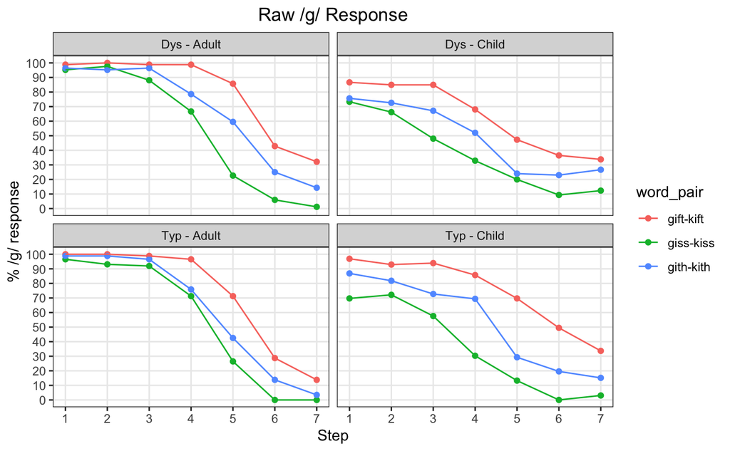

### D Pairs

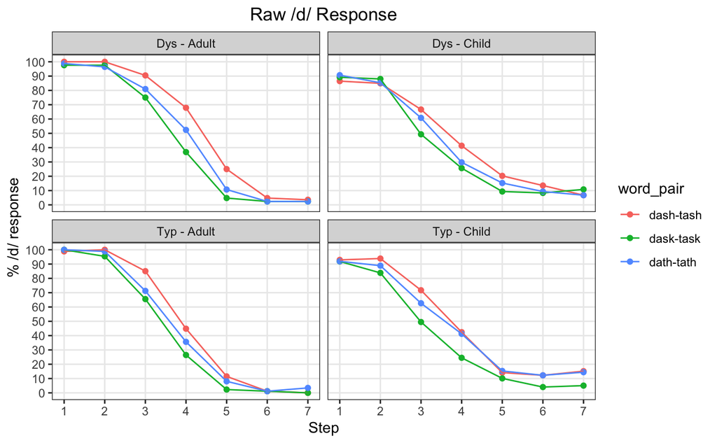

```r
lsmeans(inflection_model_all.lme.full, list(pairwise ~ isAdult|wordPairType|phonemeContr ), adjust = "tukey")
```

```
NOTE: Results may be misleading due to involvement in interactions
```

```
$`lsmeans of isAdult | wordPairType, phonemeContr`
wordPairType = 1, phonemeContr = dt:
 isAdult lsmean    SE  df lower.CL upper.CL
 0         4.23 0.141 417     3.95     4.51
 1         3.80 0.137 417     3.53     4.07

wordPairType = 2, phonemeContr = dt:
 isAdult lsmean    SE  df lower.CL upper.CL
 0         4.79 0.140 417     4.51     5.06
 1         4.48 0.137 417     4.21     4.74

wordPairType = 1, phonemeContr = gk:
 isAdult lsmean    SE  df lower.CL upper.CL
 0         2.83 0.150 418     2.53     3.12
 1         2.30 0.142 418     2.02     2.58

wordPairType = 2, phonemeContr = gk:
 isAdult lsmean    SE  df lower.CL upper.CL
 0         4.87 0.141 417     4.59     5.15
 1         3.70 0.137 417     3.43     3.97

Results are averaged over the levels of: isDys
Degrees-of-freedom method: kenward-roger
Confidence level used: 0.95

$`pairwise differences of isAdult | wordPairType, phonemeContr`
wordPairType = 1, phonemeContr = dt:
 3     estimate    SE  df t.ratio p.value
 0 - 1    0.430 0.197 417 2.184   0.0295

wordPairType = 2, phonemeContr = dt:
 3     estimate    SE  df t.ratio p.value
 0 - 1    0.312 0.196 417 1.593   0.1119

wordPairType = 1, phonemeContr = gk:
 3     estimate    SE  df t.ratio p.value
 0 - 1    0.528 0.206 418 2.562   0.0108

wordPairType = 2, phonemeContr = gk:
 3     estimate    SE  df t.ratio p.value
 0 - 1    1.176 0.197 417 5.976   <.0001

Results are averaged over the levels of: isDys
Degrees-of-freedom method: kenward-roger
```

```r
lsmeans(diff_inf_model_all.lm1, list(pairwise ~ isDys|isAdult), adjust = "tukey")
```

```
NOTE: Results may be misleading due to involvement in interactions
```

```
$`lsmeans of isDys | isAdult`
isAdult = 0:
 isDys lsmean    SE  df lower.CL upper.CL
 0      1.531 0.191 108    1.153     1.91
 1      0.930 0.211 110    0.512     1.35

isAdult = 1:
 isDys lsmean    SE  df lower.CL upper.CL
 0      0.776 0.190 102    0.399     1.15
 1      1.285 0.194 102    0.901     1.67

Results are averaged over the levels of: phonemeContr
Degrees-of-freedom method: kenward-roger
Confidence level used: 0.95

$`pairwise differences of isDys | isAdult`
isAdult = 0:
 2     estimate    SE  df t.ratio p.value
 0 - 1    0.602 0.285 109  2.113  0.0369

isAdult = 1:
 2     estimate    SE  df t.ratio p.value
 0 - 1   -0.508 0.271 102 -1.874  0.0637

Results are averaged over the levels of: phonemeContr
Degrees-of-freedom method: kenward-roger
```

## Fit Logistic Regression D

###Combine D and G

## Transform data and exclude outliers

[output not shown]

## Slope Analysis

#### Slope across conditions

- Main effect for word and age

#### Slope for neutral only

- Main effects for group and age

#Slope effects for neutral condition

## Lexical Effect

```
Type III Analysis of Variance Table with Satterthwaite's method
                Sum Sq Mean Sq NumDF DenDF F value    Pr(>F)
step           12.1807 2.03011     6   684 26.9457 < 2.2e-16 ***
group           0.0552 0.05517     1   114  0.7323   0.39392
age             0.4967 0.49674     1   114  6.5932   0.01153 *
step:group      0.3289 0.05481     6   684  0.7275   0.62754
step:age        2.8112 0.46853     6   684  6.2189 2.267e-06 ***
group:age       0.5025 0.50249     1   114  6.6696   0.01107 *
step:group:age  1.2411 0.20686     6   684  2.7456   0.01211 *
---
Signif. codes:  0 ‘***’ 0.001 ‘**’ 0.01 ‘*’ 0.05 ‘.’ 0.1 ‘ ’ 1
```

[output not shown]

### Plot Lexicality Effect

[output not shown]

###Plot lexicality effect by step/group

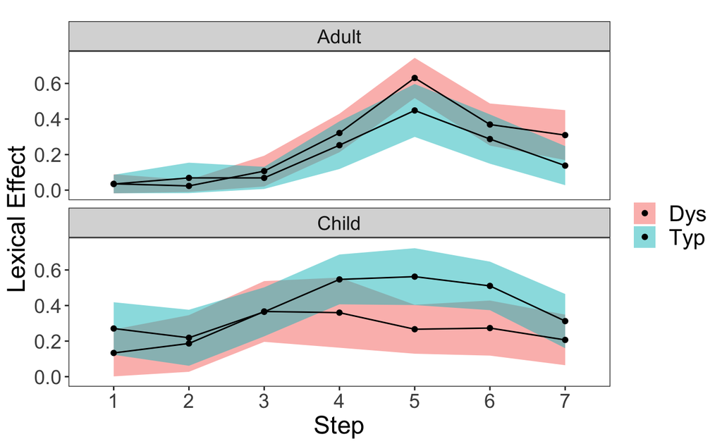

## Make logistic graphs

[output not shown]

```r
d_ends<-d%>%filter(word=='dath'|word=='gith')%>%
  filter(n_step==1|n_step==7)

d_ends$correct<-base::ifelse(d_ends$n_step==1 & d_ends$word=='dath' & d_ends$response=="D",1,
                         ifelse(d_ends$n_step=='7' & d_ends$word=='dath' & d_ends$response=='T',1,
                                ifelse(d_ends$n_step=='1' & d_ends$word=='gith' & d_ends$response=='G',1,
                                       ifelse(d_ends$n_step =='7' & d_ends$word=='gith' & d_ends$response =='K',1,0))))

d_ends_exclude<-d_ends%>%group_by(PartID,group,word)%>%
  dplyr::summarise(per_correct = (sum(correct, na.rm = T)*100/6))%>%
  filter(per_correct<100)
```